Alexander Hyde  
Phys 434 AB  
Partner: Max Wang

# Lab 7

```python
%matplotlib inline
import numpy as np
import math
import matplotlib
import matplotlib.pyplot as plt
import scipy
from scipy import stats
import pandas as pd
import pickle
plt.rcParams["figure.figsize"] = (22,8)

with open("higgs_100000_pt_1000_1200.pkl", 'rb') as f:
    higgsDF = pickle.load(f)

with open("qcd_100000_pt_1000_1200.pkl", 'rb') as f:
    qcdDF = pickle.load(f)
```

## Jet Mass

### No Cuts

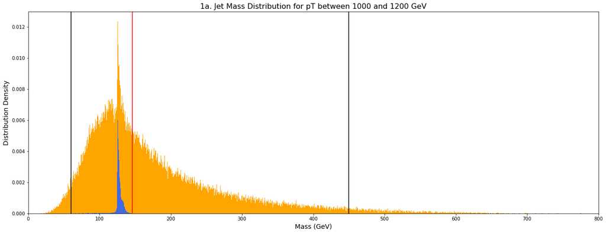

```
Expected Mass of Distribution = 145.942 GeV
Number of Higgs Jets in Distribution = 49.841
Number of QCD Jets in Distribution = 1897.7
Ratio of Higgs to Sqrt QCD Jets = 1.144
```

```python
fig,ax = plt.subplots(1,1)
bins = np.linspace(0,800,1601)
listS = [higgsDF["mass"],qcdDF["mass"]] # Mass List Stacked
listW = [np.ones(len(listS[0])) * 50, np.ones(len(listS[1])) * 2000] # Mass List Weights

plt.hist(listS,bins,stacked=True,density=True,weights=listW,color=["RoyalBlue","Orange"])
plt.xlim([0,800])
plt.title("1a. Jet Mass Distribution for pT between 1000 and 1200 GeV",fontsize=16)
plt.xlabel("Mass (GeV)",fontsize=14)
plt.ylabel("Distribution Density",fontsize=14)

sig = 0.025
def sortFunc(e):
    return e[0]
def getSignificance(s_list,sliceT):
    s_comb = []
    for i in s_list[0]:
        s_comb.append([i,50/2050,0])
    for i in s_list[1]:
        s_comb.append([i,2000/2050,1])
    s_comb.sort(key=sortFunc)
    if sliceT is not None:
        n_comb = []
        for j in range(0,len(s_comb)):
            if sliceT[0] <= s_comb[j][0] and s_comb[j][0] < sliceT[1]:
                n_comb.append(s_comb[j])
        s_comb = n_comb

    s_areaN = 0
    s_areaL = s_areaR = 0
    s_M = s_L = s_R = 0
    s_N = [0,0]
    for i in range(0,len(s_comb)):
        s_areaN = s_areaN + s_comb[i][1]
    for i in range(0,len(s_comb),1):
        s_areaL = s_areaL + s_comb[i][1]/s_areaN
        if s_areaL < sig:
            s_L = i
        elif s_areaL >= sig and s_areaL < 0.5:
            s_M = i
        else:
            break
    for i in range(len(s_comb)-1,-1,-1):
        s_areaR = s_areaR + s_comb[i][1]/s_areaN
        s_R = i
        if s_areaR >= sig:
            break
    for i in range(s_L,s_R+1,1):
        s_N[s_comb[i][2]] = s_N[s_comb[i][2]] + s_comb[i][1]*2050/100000
    return s_comb[s_M][0],s_comb[s_L][0],s_comb[s_R][0],s_N

s_M,s_L,s_R,s_N = getSignificance([higgsDF["mass"],qcdDF["mass"]],None)
plt.axvline(x=s_M,color="Red")
plt.axvline(x=s_L,color="Black")
plt.axvline(x=s_R,color="Black")
plt.show()

n_ratio = s_N[0] / math.sqrt(s_N[1])
print("Expected Mass of Distribution = " + str(np.round(s_M,3)) + " GeV")
print("Number of Higgs Jets in Distribution = " + str(np.round(s_N[0],3)))
print("Number of QCD Jets in Distribution = " + str(np.round(s_N[1],3)))
print("Ratio of Higgs to Sqrt QCD Jets = " + str(np.round(n_ratio,3)))
```

Here's a stacked distribution of the jet masses of Higgs boson jets and QCD jets that have a transverse momentum p<sub>T</sub> between 1000 and 1200 GeV. The blue histogram is the Higgs jets, and the orange is the QCD jets. It's expected that there should be 50 Higgs jets and 2000 QCD jets in this data set, resulting in a total of 2050 jets to look at.

My first calculation off of this distribution is the expected jet mass of this distribution, which I'll define as the point mass where there's a 50% chance to be either higher or lower than it. I indicated this point by the red line as seen in Figure 1. On top of this calculation, I'm also including two black lines, the area between them indicating 95% of the distribution around the expected mass. In other words, the closer the 95% uncertainty lines are to the expected mass line, the more significant the expected mass is.

Second, I calculated the ratio of $n = \frac{N_{Higgs}}{\sqrt{N_{QCD}}}$, where N<sub>Higgs</sub> and N<sub>QCD</sub> indicate the number of jets inside of the significance region between the two black lines. This ended up being 1.144, which compared to the net ratio $n_{net} = \frac{50}{\sqrt{2000}} = 1.118$, is greater, indicating that there're more Higgs to QCD jets in the significant region than there are over the entire distribution. This can be visually seen in the distribution, as the Higgs distribution is much more narrow and focused than the QCD distribution, so less of the Higgs jets get cut off by the 95% uncertainty lines than the QCD jets.

### Systematic Cuts

Here I'll make several cuts of the distribution, and plot the cut which best optimizes the n ratio and also hopefully the significance. The cuts I'll be applying are from m = 100 to 150 GeV, and then every interval of 10 GeV between 100 and 150 GeV.

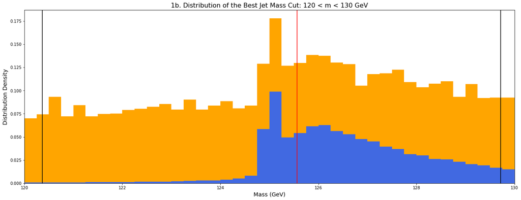

```
Expected Mass of Cut = 125.567 GeV
Number of Higgs Jets in Cut = 37.171
Number of QCD Jets in Cut = 120.76
Ratio of Higgs to Sqrt QCD Jets = 3.383
```

```python
slices = [[100,150,201],[100,110,41],[110,120,41],[120,130,41],[130,140,41],[140,150,41]]
n_max = 0
n_M = n_L = n_R = 0
n_N = [0,0]
n_slice = slices[0]
for i in range(0,len(slices)):
    s_M,s_L,s_R,s_N = getSignificance([higgsDF["mass"],qcdDF["mass"]],slices[i])
    n_ratio = s_N[0] / math.sqrt(s_N[1])
    if n_max < n_ratio:
        n_max = n_ratio
        n_M,n_L,n_R,n_N = s_M,s_L,s_R,s_N
        n_slice = slices[i]

fig,ax = plt.subplots(1,1)
bins = np.linspace(n_slice[0],n_slice[1],n_slice[2])
listS = [higgsDF["mass"],qcdDF["mass"]] # Mass List Stacked
for i in range(0,len(listS)):
    listN = []
    for j in listS[i]:
        if n_slice[0] <= j and j < n_slice[1]:
            listN.append(j)
    listS[i] = listN
listW = [np.ones(len(listS[0])) * 50, np.ones(len(listS[1])) * 2000] # Mass List Weights

plt.hist(listS,bins,stacked=True,density=True,weights=listW,color=["RoyalBlue","Orange"])
plt.xlim([n_slice[0],n_slice[1]])
plt.title("1b. Distribution of the Best Jet Mass Cut: " + str(n_slice[0]) + " < m < " + str(n_slice[1]) + " GeV",fontsize=16)
plt.xlabel("Mass (GeV)",fontsize=14)
plt.ylabel("Distribution Density",fontsize=14)

plt.axvline(x=n_M,color="Red")
plt.axvline(x=n_L,color="Black")
plt.axvline(x=n_R,color="Black")
plt.show()
print("Expected Mass of Cut = " + str(np.round(n_M,3)) + " GeV")
print("Number of Higgs Jets in Cut = " + str(np.round(n_N[0],3)))
print("Number of QCD Jets in Cut = " + str(np.round(n_N[1],3)))
print("Ratio of Higgs to Sqrt QCD Jets = " + str(np.round(n_max,3)))
```

My code based the optimization of mass cuts based on the n ratio, and in this case, it found that the best of the 6 mass cuts was the cut from 120 to 130 GeV. This cut has a very significant increase in n from 1.144 up to 3.383, meaning that jets with masses between 120 and 130 GeV are much more likely to be Higgs bosons than jets from the overall data set.

Now, I'll repeat these same calculations on different features of the jets.

## Pseudorapidity

### No Cuts

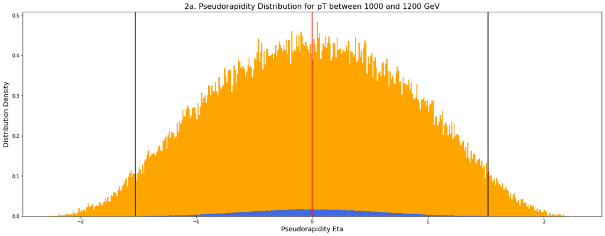

```
Expected Eta of Distribution = 0.001
Number of Higgs Jets in Distribution = 49.889
Number of QCD Jets in Distribution = 1897.64
Ratio of Higgs to Sqrt QCD Jets = 1.145
```

```python
fig,ax = plt.subplots(1,1)
bins = np.linspace(-2.5,2.5,501)
listS = [higgsDF["eta"],qcdDF["eta"]] # Mass List Stacked
listW = [np.ones(len(listS[0])) * 50, np.ones(len(listS[1])) * 2000] # Mass List Weights

plt.hist(listS,bins,stacked=True,density=True,weights=listW,color=["RoyalBlue","Orange"])
plt.xlim([-2.5,2.5])
plt.title("2a. Pseudorapidity Distribution for pT between 1000 and 1200 GeV",fontsize=16)
plt.xlabel("Pseudorapidity Eta",fontsize=14)
plt.ylabel("Distribution Density",fontsize=14)

s_M,s_L,s_R,s_N = getSignificance([higgsDF["eta"],qcdDF["eta"]],None)
plt.axvline(x=s_M,color="Red")
plt.axvline(x=s_L,color="Black")
plt.axvline(x=s_R,color="Black")
plt.show()

n_ratio = s_N[0] / math.sqrt(s_N[1])
print("Expected Eta of Distribution = " + str(np.round(s_M,3)))
print("Number of Higgs Jets in Distribution = " + str(np.round(s_N[0],3)))
print("Number of QCD Jets in Distribution = " + str(np.round(s_N[1],3)))
print("Ratio of Higgs to Sqrt QCD Jets = " + str(np.round(n_ratio,3)))
```

From the look of Figure 2a, I have little faith in this feature having any worth of examination, but I'll continue take cuts of it.

### Systematic Cuts

Here I'll make 6 cuts of pseudorapidity, starting with -1 to 1, and then 5 intervals of 0.4 that go between -1 and 1.

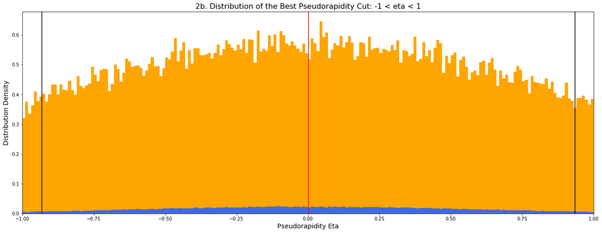

```
Expected Eta of Cut = 0.001
Number of Higgs Jets in Cut = 45.518
Number of QCD Jets in Cut = 1415.48
Ratio of Higgs to Sqrt QCD Jets = 1.21
```

```python
slices = [[-1,1,201],[-1,-0.6,41],[-0.6,-0.2,41],[-0.2,0.2,41],[0.2,0.6,41],[0.6,1,41]]
n_max = 0
n_M = n_L = n_R = 0
n_N = [0,0]
n_slice = slices[0]
for i in range(0,len(slices)):
    s_M,s_L,s_R,s_N = getSignificance([higgsDF["eta"],qcdDF["eta"]],slices[i])
    n_ratio = s_N[0] / math.sqrt(s_N[1])
    if n_max < n_ratio:
        n_max = n_ratio
        n_M,n_L,n_R,n_N = s_M,s_L,s_R,s_N
        n_slice = slices[i]

fig,ax = plt.subplots(1,1)
bins = np.linspace(n_slice[0],n_slice[1],n_slice[2])
listS = [higgsDF["eta"],qcdDF["eta"]] # List Stacked
for i in range(0,len(listS)):
    listN = []
    for j in listS[i]:
        if n_slice[0] <= j and j < n_slice[1]:
            listN.append(j)
    listS[i] = listN
listW = [np.ones(len(listS[0])) * 50, np.ones(len(listS[1])) * 2000] # List Weights

plt.hist(listS,bins,stacked=True,density=True,weights=listW,color=["RoyalBlue","Orange"])
plt.xlim([n_slice[0],n_slice[1]])
plt.title("2b. Distribution of the Best Pseudorapidity Cut: " + str(n_slice[0]) + " < eta < " + str(n_slice[1]),fontsize=16)
plt.xlabel("Pseudorapidity Eta",fontsize=14)
plt.ylabel("Distribution Density",fontsize=14)

plt.axvline(x=n_M,color="Red")
plt.axvline(x=n_L,color="Black")
plt.axvline(x=n_R,color="Black")
plt.show()
print("Expected Eta of Cut = " + str(np.round(n_M,3)))
print("Number of Higgs Jets in Cut = " + str(np.round(n_N[0],3)))
print("Number of QCD Jets in Cut = " + str(np.round(n_N[1],3)))
print("Ratio of Higgs to Sqrt QCD Jets = " + str(np.round(n_max,3)))
```

The n ratio in this case is very insignificantly larger than what we started with, going from 1.118 to 1.21, I wouldn't recommend using pseudorapidity to isolate Higgs jets as a result. One mildly interesting note is that the most significant cut wasn't a thin one, but a large one going from -1 < eta < 1.

## Azimuthal Angle

### No Cuts

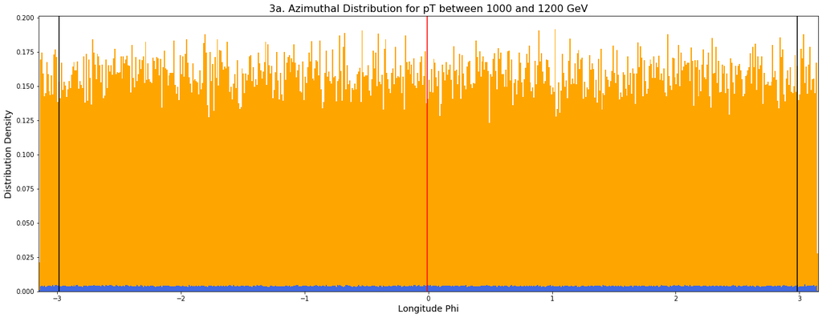

```
Expected Phi of Distribution = -0.009
Number of Higgs Jets in Distribution = 47.47
Number of QCD Jets in Distribution = 1900.06
Ratio of Higgs to Sqrt QCD Jets = 1.089
```

```python
fig,ax = plt.subplots(1,1)
bins = np.linspace(-3.15,3.15,631)
listS = [higgsDF["phi"],qcdDF["phi"]] # Mass List Stacked
listW = [np.ones(len(listS[0])) * 50, np.ones(len(listS[1])) * 2000] # Mass List Weights

plt.hist(listS,bins,stacked=True,density=True,weights=listW,color=["RoyalBlue","Orange"])
plt.xlim([-3.15,3.15])
plt.title("3a. Azimuthal Distribution for pT between 1000 and 1200 GeV",fontsize=16)
plt.xlabel("Longitude Phi",fontsize=14)
plt.ylabel("Distribution Density",fontsize=14)

s_M,s_L,s_R,s_N = getSignificance([higgsDF["phi"],qcdDF["phi"]],None)
plt.axvline(x=s_M,color="Red")
plt.axvline(x=s_L,color="Black")
plt.axvline(x=s_R,color="Black")
plt.show()

n_ratio = s_N[0] / math.sqrt(s_N[1])
print("Expected Phi of Distribution = " + str(np.round(s_M,3)))
print("Number of Higgs Jets in Distribution = " + str(np.round(s_N[0],3)))
print("Number of QCD Jets in Distribution = " + str(np.round(s_N[1],3)))
print("Ratio of Higgs to Sqrt QCD Jets = " + str(np.round(n_ratio,3)))
```

This distribution is just clearly not worth taking cuts out of, since both the Higgs and QCD jets are fairly, visibly uniform across the distribution.

## Transverse Momentum

### No Cuts

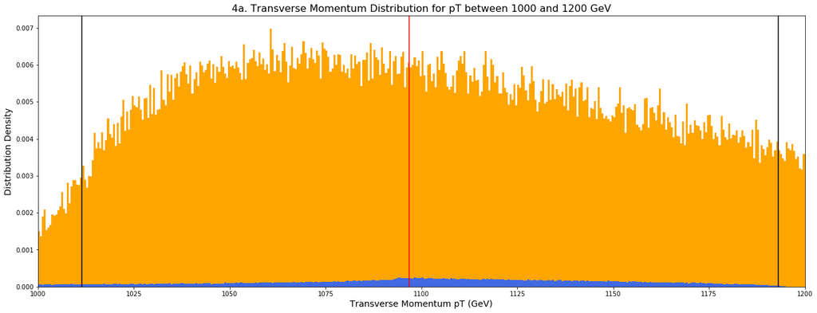

```
Expected pT of Distribution = 1096.706
Number of Higgs Jets in Distribution = 48.471
Number of QCD Jets in Distribution = 1899.04
Ratio of Higgs to Sqrt QCD Jets = 1.112
```

```python
fig,ax = plt.subplots(1,1)
bins = np.linspace(1000,1200,401)
listS = [higgsDF["pt"],qcdDF["pt"]] # Mass List Stacked
listW = [np.ones(len(listS[0])) * 50, np.ones(len(listS[1])) * 2000] # Mass List Weights

plt.hist(listS,bins,stacked=True,density=True,weights=listW,color=["RoyalBlue","Orange"])
plt.xlim([1000,1200])
plt.title("4a. Transverse Momentum Distribution for pT between 1000 and 1200 GeV",fontsize=16)
plt.xlabel("Transverse Momentum pT (GeV)",fontsize=14)
plt.ylabel("Distribution Density",fontsize=14)

s_M,s_L,s_R,s_N = getSignificance([higgsDF["pt"],qcdDF["pt"]],None)
plt.axvline(x=s_M,color="Red")
plt.axvline(x=s_L,color="Black")
plt.axvline(x=s_R,color="Black")
plt.show()

n_ratio = s_N[0] / math.sqrt(s_N[1])
print("Expected pT of Distribution = " + str(np.round(s_M,3)))
print("Number of Higgs Jets in Distribution = " + str(np.round(s_N[0],3)))
print("Number of QCD Jets in Distribution = " + str(np.round(s_N[1],3)))
print("Ratio of Higgs to Sqrt QCD Jets = " + str(np.round(n_ratio,3)))
```

### Systematic Cuts

I'll cut from 1075 to 1155 GeV, and then 8 intervals of 10 GeV between 1075 and 1155 GeV, since that's where the Higgs jet distribution is largest.

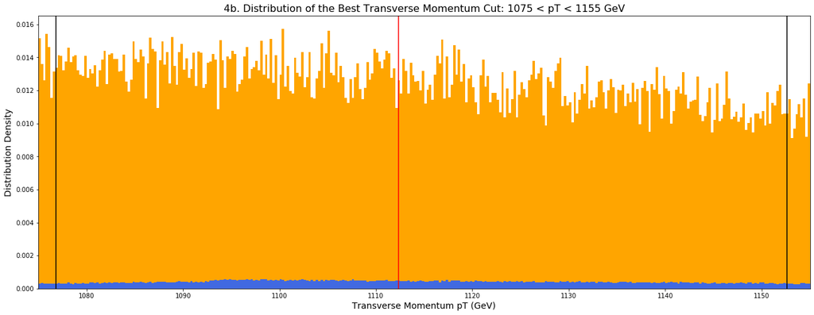

```
Expected pT of Cut = 1112.349 GeV
Number of Higgs Jets in Cut = 28.432
Number of QCD Jets in Cut = 836.8
Ratio of Higgs to Sqrt QCD Jets = 0.983
```

```python
slices = [[1075,1155,321],[1075,1085,41],[1085,1095,41],[1095,1105,41],[1105,1115,41],[1115,1125,41],[1125,1135,41],[1135,1145,41],[1145,1155,41]]
n_max = 0
n_M = n_L = n_R = 0
n_N = [0,0]
n_slice = slices[0]
for i in range(0,len(slices)):
    s_M,s_L,s_R,s_N = getSignificance([higgsDF["pt"],qcdDF["pt"]],slices[i])
    n_ratio = s_N[0] / math.sqrt(s_N[1])
    if n_max < n_ratio:
        n_max = n_ratio
        n_M,n_L,n_R,n_N = s_M,s_L,s_R,s_N
        n_slice = slices[i]

fig,ax = plt.subplots(1,1)
bins = np.linspace(n_slice[0],n_slice[1],n_slice[2])
listS = [higgsDF["pt"],qcdDF["pt"]] # List Stacked
for i in range(0,len(listS)):
    listN = []
    for j in listS[i]:
        if n_slice[0] <= j and j < n_slice[1]:
            listN.append(j)
    listS[i] = listN
listW = [np.ones(len(listS[0])) * 50, np.ones(len(listS[1])) * 2000] # List Weights

plt.hist(listS,bins,stacked=True,density=True,weights=listW,color=["RoyalBlue","Orange"])
plt.xlim([n_slice[0],n_slice[1]])
plt.title("4b. Distribution of the Best Transverse Momentum Cut: " + str(n_slice[0]) + " < pT < " + str(n_slice[1]) + " GeV",fontsize=16)
plt.xlabel("Transverse Momentum pT (GeV)",fontsize=14)
plt.ylabel("Distribution Density",fontsize=14)

plt.axvline(x=n_M,color="Red")
plt.axvline(x=n_L,color="Black")
plt.axvline(x=n_R,color="Black")
plt.show()
print("Expected pT of Cut = " + str(np.round(n_M,3)) + " GeV")
print("Number of Higgs Jets in Cut = " + str(np.round(n_N[0],3)))
print("Number of QCD Jets in Cut = " + str(np.round(n_N[1],3)))
print("Ratio of Higgs to Sqrt QCD Jets = " + str(np.round(n_max,3)))
```

This time, the best cut's ratio is embarrassingly worse than the net distribution's ratio, I wouldn't count on using transverse momentum to discriminate Higgs jets with.

## Angularity

### No Cuts

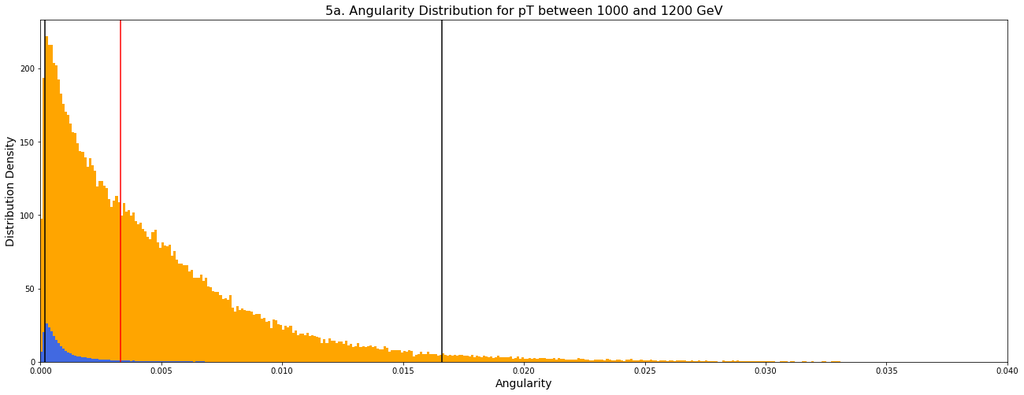

```
Expected Angularity of Distribution = 0.003
Number of Higgs Jets in Distribution = 45.489
Number of QCD Jets in Distribution = 1902.04
Ratio of Higgs to Sqrt QCD Jets = 1.043
```

```python
fig,ax = plt.subplots(1,1)
bins = np.linspace(0,0.04,401)
listS = [higgsDF["angularity"],qcdDF["angularity"]] # Mass List Stacked
listW = [np.ones(len(listS[0])) * 50, np.ones(len(listS[1])) * 2000] # Mass List Weights

plt.hist(listS,bins,stacked=True,density=True,weights=listW,color=["RoyalBlue","Orange"])
plt.xlim([0,0.04])
plt.title("5a. Angularity Distribution for pT between 1000 and 1200 GeV",fontsize=16)
plt.xlabel("Angularity",fontsize=14)
plt.ylabel("Distribution Density",fontsize=14)

s_M,s_L,s_R,s_N = getSignificance([higgsDF["angularity"],qcdDF["angularity"]],None)
plt.axvline(x=s_M,color="Red")
plt.axvline(x=s_L,color="Black")
plt.axvline(x=s_R,color="Black")
plt.show()

n_ratio = s_N[0] / math.sqrt(s_N[1])
print("Expected Angularity of Distribution = " + str(np.round(s_M,3)))
print("Number of Higgs Jets in Distribution = " + str(np.round(s_N[0],3)))
print("Number of QCD Jets in Distribution = " + str(np.round(s_N[1],3)))
print("Ratio of Higgs to Sqrt QCD Jets = " + str(np.round(n_ratio,3)))
```

### Systematic Cuts

Here I'll take a cut from 0 to 0.005, and 5 intervals of 0.001 between 0 and 0.005.

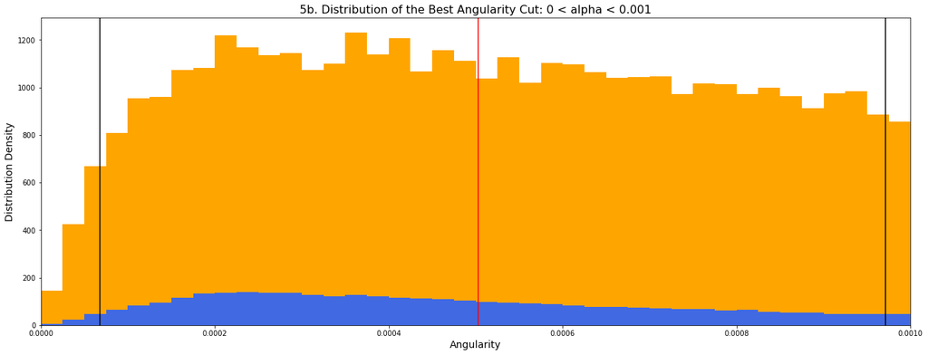

```
Expected Angularity of Cut = 0.001
Number of Higgs Jets in Cut = 32.238
Number of QCD Jets in Cut = 338.48
Ratio of Higgs to Sqrt QCD Jets = 1.752
```

```python
slices = [[0,0.005,201],[0,0.001,41],[0.001,0.002,41],[0.002,0.003,41],[0.003,0.004,41],[0.004,0.005,41]]
n_max = 0
n_M = n_L = n_R = 0
n_N = [0,0]
n_slice = slices[0]
for i in range(0,len(slices)):
    s_M,s_L,s_R,s_N = getSignificance([higgsDF["angularity"],qcdDF["angularity"]],slices[i])
    n_ratio = s_N[0] / math.sqrt(s_N[1])
    if n_max < n_ratio:
        n_max = n_ratio
        n_M,n_L,n_R,n_N = s_M,s_L,s_R,s_N
        n_slice = slices[i]

fig,ax = plt.subplots(1,1)
bins = np.linspace(n_slice[0],n_slice[1],n_slice[2])
listS = [higgsDF["angularity"],qcdDF["angularity"]] # List Stacked
for i in range(0,len(listS)):
    listN = []
    for j in listS[i]:
        if n_slice[0] <= j and j < n_slice[1]:
            listN.append(j)
    listS[i] = listN
listW = [np.ones(len(listS[0])) * 50, np.ones(len(listS[1])) * 2000] # List Weights

plt.hist(listS,bins,stacked=True,density=True,weights=listW,color=["RoyalBlue","Orange"])
plt.xlim([n_slice[0],n_slice[1]])
plt.title("5b. Distribution of the Best Angularity Cut: " + str(n_slice[0]) + " < alpha < " + str(n_slice[1]),fontsize=16)
plt.xlabel("Angularity",fontsize=14)
plt.ylabel("Distribution Density",fontsize=14)

plt.axvline(x=n_M,color="Red")
plt.axvline(x=n_L,color="Black")
plt.axvline(x=n_R,color="Black")
plt.show()
print("Expected Angularity of Cut = " + str(np.round(n_M,3)))
print("Number of Higgs Jets in Cut = " + str(np.round(n_N[0],3)))
print("Number of QCD Jets in Cut = " + str(np.round(n_N[1],3)))
print("Ratio of Higgs to Sqrt QCD Jets = " + str(np.round(n_max,3)))
```

The best cut of angularity goes from 0 to 0.001, and has a n ratio of 1.752, which is decent compared to some other jet features I've examined so far.

## Energy-Energy Correlation Order 2

### No Cuts

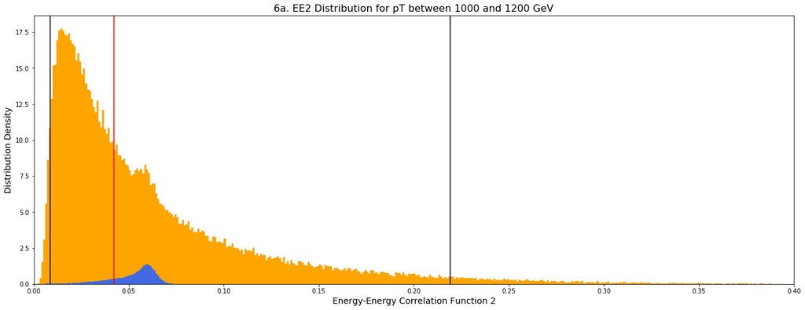

```
Expected ee2 of Distribution = 0.042
Number of Higgs Jets in Distribution = 49.886
Number of QCD Jets in Distribution = 1897.66
Ratio of Higgs to Sqrt QCD Jets = 1.145
```

```python
fig,ax = plt.subplots(1,1)
bins = np.linspace(0,0.4,401)
listS = [higgsDF["ee2"],qcdDF["ee2"]] # Mass List Stacked
listW = [np.ones(len(listS[0])) * 50, np.ones(len(listS[1])) * 2000] # Mass List Weights

plt.hist(listS,bins,stacked=True,density=True,weights=listW,color=["RoyalBlue","Orange"])
plt.xlim([0,0.4])
plt.title("6a. EE2 Distribution for pT between 1000 and 1200 GeV",fontsize=16)
plt.xlabel("Energy-Energy Correlation Function 2",fontsize=14)
plt.ylabel("Distribution Density",fontsize=14)

s_M,s_L,s_R,s_N = getSignificance([higgsDF["ee2"],qcdDF["ee2"]],None)
plt.axvline(x=s_M,color="Red")
plt.axvline(x=s_L,color="Black")
plt.axvline(x=s_R,color="Black")
plt.show()

n_ratio = s_N[0] / math.sqrt(s_N[1])
print("Expected ee2 of Distribution = " + str(np.round(s_M,3)))
print("Number of Higgs Jets in Distribution = " + str(np.round(s_N[0],3)))
print("Number of QCD Jets in Distribution = " + str(np.round(s_N[1],3)))
print("Ratio of Higgs to Sqrt QCD Jets = " + str(np.round(n_ratio,3)))
```

This is the first promising feature since the jet mass, since the Higgs distribution peaks at a place where the QCD distribution isn't peaked.

### Systematic Cuts

I'll take a cut from 0.02 to 0.08, and 5 cuts of 0.02 between 0.02 and 0.08.

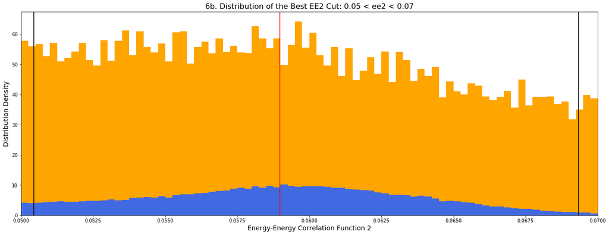

```
Expected ee2 of Cut = 0.059
Number of Higgs Jets in Cut = 32.702
Number of QCD Jets in Cut = 242.12
Ratio of Higgs to Sqrt QCD Jets = 2.102
```

```python
slices = [[0.02,0.08,241],[0.02,0.04,81],[0.03,0.05,81],[0.04,0.06,81],[0.05,0.07,81],[0.06,0.08,81]]
n_max = 0
n_M = n_L = n_R = 0
n_N = [0,0]
n_slice = slices[0]
for i in range(0,len(slices)):
    s_M,s_L,s_R,s_N = getSignificance([higgsDF["ee2"],qcdDF["ee2"]],slices[i])
    n_ratio = s_N[0] / math.sqrt(s_N[1])
    if n_max < n_ratio:
        n_max = n_ratio
        n_M,n_L,n_R,n_N = s_M,s_L,s_R,s_N
        n_slice = slices[i]

fig,ax = plt.subplots(1,1)
bins = np.linspace(n_slice[0],n_slice[1],n_slice[2])
listS = [higgsDF["ee2"],qcdDF["ee2"]] # List Stacked
for i in range(0,len(listS)):
    listN = []
    for j in listS[i]:
        if n_slice[0] <= j and j < n_slice[1]:
            listN.append(j)
    listS[i] = listN
listW = [np.ones(len(listS[0])) * 50, np.ones(len(listS[1])) * 2000] # List Weights

plt.hist(listS,bins,stacked=True,density=True,weights=listW,color=["RoyalBlue","Orange"])
plt.xlim([n_slice[0],n_slice[1]])
plt.title("6b. Distribution of the Best EE2 Cut: " + str(n_slice[0]) + " < ee2 < " + str(n_slice[1]),fontsize=16)
plt.xlabel("Energy-Energy Correlation Function 2",fontsize=14)
plt.ylabel("Distribution Density",fontsize=14)

plt.axvline(x=n_M,color="Red")
plt.axvline(x=n_L,color="Black")
plt.axvline(x=n_R,color="Black")
plt.show()
print("Expected ee2 of Cut = " + str(np.round(n_M,3)))
print("Number of Higgs Jets in Cut = " + str(np.round(n_N[0],3)))
print("Number of QCD Jets in Cut = " + str(np.round(n_N[1],3)))
print("Ratio of Higgs to Sqrt QCD Jets = " + str(np.round(n_max,3)))
```

The best cut of EE2 goes from 0.05 to 0.07, and has a respectable n ratio of 2.102.

## Energy-Energy Correlation Order 3

### No Cuts

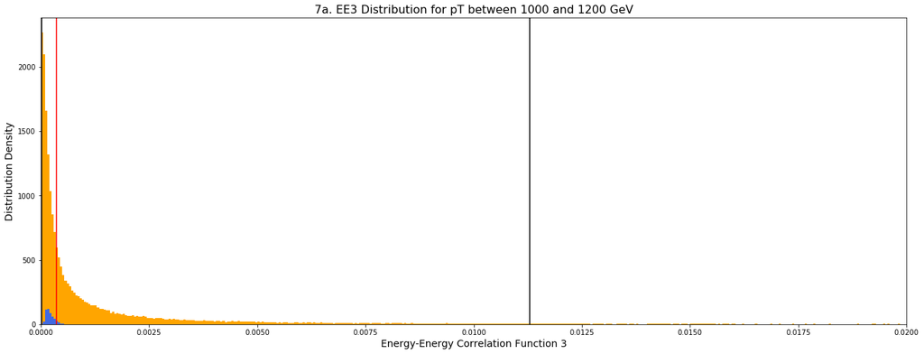

```
Expected ee3 of Distribution = 0.00036
Number of Higgs Jets in Distribution = 49.862
Number of QCD Jets in Distribution = 1897.68
Ratio of Higgs to Sqrt QCD Jets = 1.145
```

```python
fig,ax = plt.subplots(1,1)
bins = np.linspace(0,0.02,401)
listS = [higgsDF["ee3"],qcdDF["ee3"]] # Mass List Stacked
listW = [np.ones(len(listS[0])) * 50, np.ones(len(listS[1])) * 2000] # Mass List Weights

plt.hist(listS,bins,stacked=True,density=True,weights=listW,color=["RoyalBlue","Orange"])
plt.xlim([0,0.02])
plt.title("7a. EE3 Distribution for pT between 1000 and 1200 GeV",fontsize=16)
plt.xlabel("Energy-Energy Correlation Function 3",fontsize=14)
plt.ylabel("Distribution Density",fontsize=14)

s_M,s_L,s_R,s_N = getSignificance([higgsDF["ee3"],qcdDF["ee3"]],None)
plt.axvline(x=s_M,color="Red")
plt.axvline(x=s_L,color="Black")
plt.axvline(x=s_R,color="Black")
plt.show()

n_ratio = s_N[0] / math.sqrt(s_N[1])
print("Expected ee3 of Distribution = " + str(np.round(s_M,5)))
print("Number of Higgs Jets in Distribution = " + str(np.round(s_N[0],3)))
print("Number of QCD Jets in Distribution = " + str(np.round(s_N[1],3)))
print("Ratio of Higgs to Sqrt QCD Jets = " + str(np.round(n_ratio,3)))
```

### Systematic Cuts

The cuts I'll take will be from 0 to 0.001, and 9 intervals of 0.0002 in that range.

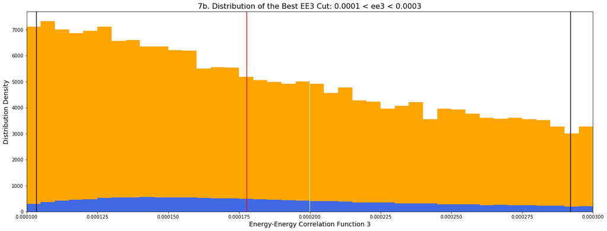

```
Expected ee3 of Cut = 0.00018
Number of Higgs Jets in Cut = 37.136
Number of QCD Jets in Cut = 433.1
Ratio of Higgs to Sqrt QCD Jets = 1.784
```

```python
slices = [[0,0.001,201],[0,0.0002,41],[0.0001,0.0003,41],[0.0002,0.0004,41],[0.0003,0.0005,41],[0.0004,0.0006,41],[0.0005,0.0007,41],[0.0006,0.0008,41],[0.0007,0.0009,41],[0.0008,0.001,41]]
n_max = 0
n_M = n_L = n_R = 0
n_N = [0,0]
n_slice = slices[0]
for i in range(0,len(slices)):
    s_M,s_L,s_R,s_N = getSignificance([higgsDF["ee3"],qcdDF["ee3"]],slices[i])
    n_ratio = s_N[0] / math.sqrt(s_N[1])
    if n_max < n_ratio:
        n_max = n_ratio
        n_M,n_L,n_R,n_N = s_M,s_L,s_R,s_N
        n_slice = slices[i]

fig,ax = plt.subplots(1,1)
bins = np.linspace(n_slice[0],n_slice[1],n_slice[2])
listS = [higgsDF["ee3"],qcdDF["ee3"]] # List Stacked
for i in range(0,len(listS)):
    listN = []
    for j in listS[i]:
        if n_slice[0] <= j and j < n_slice[1]:
            listN.append(j)
    listS[i] = listN
listW = [np.ones(len(listS[0])) * 50, np.ones(len(listS[1])) * 2000] # List Weights

plt.hist(listS,bins,stacked=True,density=True,weights=listW,color=["RoyalBlue","Orange"])
plt.xlim([n_slice[0],n_slice[1]])
plt.title("7b. Distribution of the Best EE3 Cut: " + str(n_slice[0]) + " < ee3 < " + str(n_slice[1]),fontsize=16)
plt.xlabel("Energy-Energy Correlation Function 3",fontsize=14)
plt.ylabel("Distribution Density",fontsize=14)

plt.axvline(x=n_M,color="Red")
plt.axvline(x=n_L,color="Black")
plt.axvline(x=n_R,color="Black")
plt.show()
print("Expected ee3 of Cut = " + str(np.round(n_M,5)))
print("Number of Higgs Jets in Cut = " + str(np.round(n_N[0],3)))
print("Number of QCD Jets in Cut = " + str(np.round(n_N[1],3)))
print("Ratio of Higgs to Sqrt QCD Jets = " + str(np.round(n_max,3)))
```

EE3 also has a decent n ratio of 1.784 for the cut of EE3 between 0.0001 and 0.0003.

## D<sub>2</sub> Ratio

### No Cuts

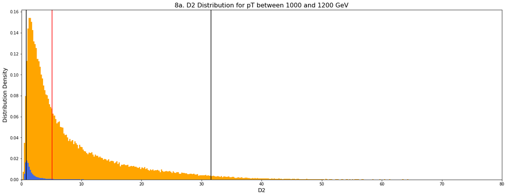

```
Expected D2 of Distribution = 5.13604
Number of Higgs Jets in Distribution = 40.671
Number of QCD Jets in Distribution = 1906.86
Ratio of Higgs to Sqrt QCD Jets = 0.931
```

```python
fig,ax = plt.subplots(1,1)
bins = np.linspace(0,80,401)
listS = [higgsDF["d2"],qcdDF["d2"]] # Mass List Stacked
listW = [np.ones(len(listS[0])) * 50, np.ones(len(listS[1])) * 2000] # Mass List Weights

plt.hist(listS,bins,stacked=True,density=True,weights=listW,color=["RoyalBlue","Orange"])
plt.xlim([0,80])
plt.title("8a. D2 Distribution for pT between 1000 and 1200 GeV",fontsize=16)
plt.xlabel("D2",fontsize=14)
plt.ylabel("Distribution Density",fontsize=14)

s_M,s_L,s_R,s_N = getSignificance([higgsDF["d2"],qcdDF["d2"]],None)
plt.axvline(x=s_M,color="Red")
plt.axvline(x=s_L,color="Black")
plt.axvline(x=s_R,color="Black")
plt.show()

n_ratio = s_N[0] / math.sqrt(s_N[1])
print("Expected D2 of Distribution = " + str(np.round(s_M,5)))
print("Number of Higgs Jets in Distribution = " + str(np.round(s_N[0],3)))
print("Number of QCD Jets in Distribution = " + str(np.round(s_N[1],3)))
print("Ratio of Higgs to Sqrt QCD Jets = " + str(np.round(n_ratio,3)))
```

I postulated in an earlier lab (Lab 5) that one way to discriminate between Higgs and QCD jets would be to isolate jets with low D2 ratios and high EE2 values. Here I'll just examine low D2 ratios, as you can already see that's where most of the Higgs jets are.

### Systematic Cuts

I'll take cuts starting with 0 to 6, and 5 intervals of 2 in that range.

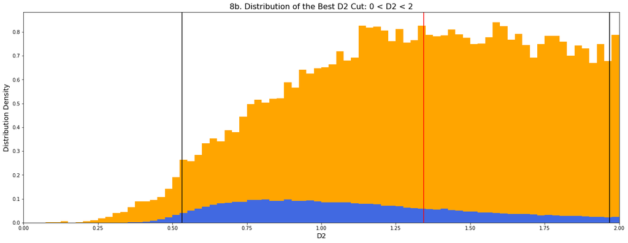

```
Expected D2 of Cut = 1.34419
Number of Higgs Jets in Cut = 35.453
Number of QCD Jets in Cut = 346.32
Ratio of Higgs to Sqrt QCD Jets = 1.905
```

```python
slices = [[0,6,241],[0,2,81],[1,3,81],[2,4,81],[3,5,81],[4,6,81]]
n_max = 0
n_M = n_L = n_R = 0
n_N = [0,0]
n_slice = slices[0]
for i in range(0,len(slices)):
    s_M,s_L,s_R,s_N = getSignificance([higgsDF["d2"],qcdDF["d2"]],slices[i])
    n_ratio = s_N[0] / math.sqrt(s_N[1])
    if n_max < n_ratio:
        n_max = n_ratio
        n_M,n_L,n_R,n_N = s_M,s_L,s_R,s_N
        n_slice = slices[i]

fig,ax = plt.subplots(1,1)
bins = np.linspace(n_slice[0],n_slice[1],n_slice[2])
listS = [higgsDF["d2"],qcdDF["d2"]] # List Stacked
for i in range(0,len(listS)):
    listN = []
    for j in listS[i]:
        if n_slice[0] <= j and j < n_slice[1]:
            listN.append(j)
    listS[i] = listN
listW = [np.ones(len(listS[0])) * 50, np.ones(len(listS[1])) * 2000] # List Weights

plt.hist(listS,bins,stacked=True,density=True,weights=listW,color=["RoyalBlue","Orange"])
plt.xlim([n_slice[0],n_slice[1]])
plt.title("8b. Distribution of the Best D2 Cut: " + str(n_slice[0]) + " < D2 < " + str(n_slice[1]),fontsize=16)
plt.xlabel("D2",fontsize=14)
plt.ylabel("Distribution Density",fontsize=14)

plt.axvline(x=n_M,color="Red")
plt.axvline(x=n_L,color="Black")
plt.axvline(x=n_R,color="Black")
plt.show()
print("Expected D2 of Cut = " + str(np.round(n_M,5)))
print("Number of Higgs Jets in Cut = " + str(np.round(n_N[0],3)))
print("Number of QCD Jets in Cut = " + str(np.round(n_N[1],3)))
print("Ratio of Higgs to Sqrt QCD Jets = " + str(np.round(n_max,3)))
```

While this n ratio of 1.905 isn't as impressive as the optimal mass cut's n ratio, I'll still combine a cut of high EE2 with low D2 later on.

## Subjet Distance

### No Cuts

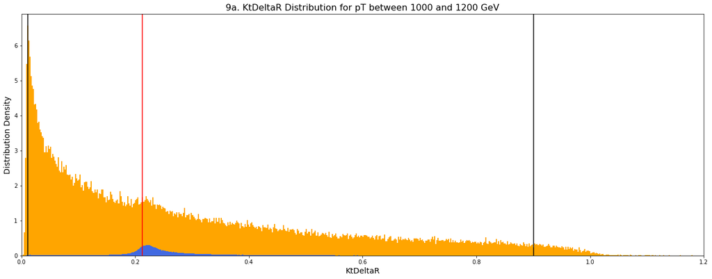

```
Expected KtDeltaR of Distribution = 0.2126
Number of Higgs Jets in Distribution = 49.916
Number of QCD Jets in Distribution = 1897.62
Ratio of Higgs to Sqrt QCD Jets = 1.146
```

```python
fig,ax = plt.subplots(1,1)
bins = np.linspace(0,1.2,601)
listS = [higgsDF["KtDeltaR"],qcdDF["KtDeltaR"]] # Mass List Stacked
listW = [np.ones(len(listS[0])) * 50, np.ones(len(listS[1])) * 2000] # Mass List Weights

plt.hist(listS,bins,stacked=True,density=True,weights=listW,color=["RoyalBlue","Orange"])
plt.xlim([0,1.2])
plt.title("9a. KtDeltaR Distribution for pT between 1000 and 1200 GeV",fontsize=16)
plt.xlabel("KtDeltaR",fontsize=14)
plt.ylabel("Distribution Density",fontsize=14)

s_M,s_L,s_R,s_N = getSignificance([higgsDF["KtDeltaR"],qcdDF["KtDeltaR"]],None)
plt.axvline(x=s_M,color="Red")
plt.axvline(x=s_L,color="Black")
plt.axvline(x=s_R,color="Black")
plt.show()

n_ratio = s_N[0] / math.sqrt(s_N[1])
print("Expected KtDeltaR of Distribution = " + str(np.round(s_M,5)))
print("Number of Higgs Jets in Distribution = " + str(np.round(s_N[0],3)))
print("Number of QCD Jets in Distribution = " + str(np.round(s_N[1],3)))
print("Ratio of Higgs to Sqrt QCD Jets = " + str(np.round(n_ratio,3)))
```

Similar to EE2 in Figure 6a, the Higgs distribution forms a visible bump on an otherwise smooth(ish) QCD distribution.

### Systematic Cuts

Here I'll take a large cut from 0.15 to 0.45, and then 5 intervals of 0.1 in that range.

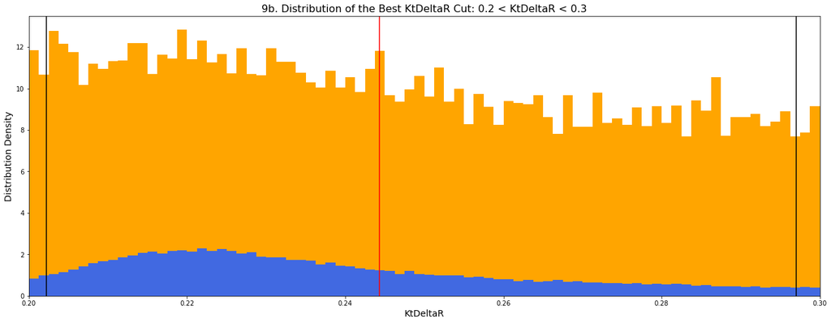

```
Expected KtDeltaR of Cut = 0.24434
Number of Higgs Jets in Cut = 31.204
Number of QCD Jets in Cut = 234.18
Ratio of Higgs to Sqrt QCD Jets = 2.039
```

```python
slices = [[0.15,0.45,241],[0.15,0.25,81],[0.2,0.3,81],[0.25,0.35,81],[0.3,0.4,81],[0.35,0.45,81]]
n_max = 0
n_M = n_L = n_R = 0
n_N = [0,0]
n_slice = slices[0]
for i in range(0,len(slices)):
    s_M,s_L,s_R,s_N = getSignificance([higgsDF["KtDeltaR"],qcdDF["KtDeltaR"]],slices[i])
    n_ratio = s_N[0] / math.sqrt(s_N[1])
    if n_max < n_ratio:
        n_max = n_ratio
        n_M,n_L,n_R,n_N = s_M,s_L,s_R,s_N
        n_slice = slices[i]

fig,ax = plt.subplots(1,1)
bins = np.linspace(n_slice[0],n_slice[1],n_slice[2])
listS = [higgsDF["KtDeltaR"],qcdDF["KtDeltaR"]] # List Stacked
for i in range(0,len(listS)):
    listN = []
    for j in listS[i]:
        if n_slice[0] <= j and j < n_slice[1]:
            listN.append(j)
    listS[i] = listN
listW = [np.ones(len(listS[0])) * 50, np.ones(len(listS[1])) * 2000] # List Weights

plt.hist(listS,bins,stacked=True,density=True,weights=listW,color=["RoyalBlue","Orange"])
plt.xlim([n_slice[0],n_slice[1]])
plt.title("9b. Distribution of the Best KtDeltaR Cut: " + str(n_slice[0]) + " < KtDeltaR < " + str(n_slice[1]),fontsize=16)
plt.xlabel("KtDeltaR",fontsize=14)
plt.ylabel("Distribution Density",fontsize=14)

plt.axvline(x=n_M,color="Red")
plt.axvline(x=n_L,color="Black")
plt.axvline(x=n_R,color="Black")
plt.show()
print("Expected KtDeltaR of Cut = " + str(np.round(n_M,5)))
print("Number of Higgs Jets in Cut = " + str(np.round(n_N[0],3)))
print("Number of QCD Jets in Cut = " + str(np.round(n_N[1],3)))
print("Ratio of Higgs to Sqrt QCD Jets = " + str(np.round(n_max,3)))
```

This n ratio of 2.039 on its own is fairly impressive, just like the EE2's n ratio.